# CSE 5243 - Introduction to Data Mining

## Section: 5.2 - Configure and Run the Algorithm

- Do this for (at least) two variations of the configuration settings (if any). Explain all configuration parameter values you chose, and why you chose them.
- For Each Run:
1. Compute the within-cluster WSS, the between-cluster BSS, and the Total SSE (WSS+BSS), and compute the running time.
2. Create a scatterplot, overlaying the true cluster with the cluster produced by your algorithm. (Or alternatively, create two side by side scatterplots).
3. Create a cross tabulation matrix (i.e., confusion matrix) comparing the true and assigned clusters, and the basic measures (precision, recall, F1, accuracy, etc. - see classification_report). Note that you may need to "match up" the true and assigned cluster labels. See the linear-sum-assignment and Hungarian algorithm references, for example.

```python
# Load the data
data = pd.read_csv('large2_Xydf.csv')

X = data[['X0', 'X1']].values
true_labels = data['y'].values

WSS, BSS, total_SSE = calculate_true_clusters(X, true_labels)
print(f"True WSS: {round(WSS, 4)}\nTrue BSS: {round(BSS, 4)}\nTotal SSE: {round(total_SSE, 4)}")

X = StandardScaler().fit_transform(X)
```

```
True WSS: 1917.7276
True BSS: 1219.5688
Total SSE: 3137.2964
```

```python
# Function to perform Agglomerative Clustering and plot the dendrogram
def dendrogram_clustering(X, n_clusters):
    start_time = time.time()

    # Fit Agglomerative Clustering
    agglomerative = AgglomerativeClustering(n_clusters=n_clusters, linkage='ward')
    predicted_labels = agglomerative.fit_predict(X)

    # Compute WSS, BSS, and total SSE (using the same function from previous)
    WSS, BSS, total_SSE = calculate_true_clusters(X, predicted_labels)

    end_time = time.time()
    execution_time = end_time - start_time

    return WSS, BSS, total_SSE, execution_time, predicted_labels
```

```python
# Run dendrogram clustering for a specific number of clusters (e.g., 3 clusters)
results_agg = {}
for n_clusters in range(2, 8):
    WSS, BSS, total_SSE, execution_time, predicted_labels = dendrogram_clustering(X, n_clusters)
    results_agg[n_clusters] = {'WSS': round(WSS, 4), 'BSS': round(BSS, 4), 'Total SSE': round(total_SSE, 4), 'Execution Time': round(execution_time, 4)}

for key, value in results_agg.items():
    print("For Agglomerative params=", key, ":", value)
```

```
For Agglomerative params= 2 : {'WSS': 2915.6324, 'BSS': 3084.3676, 'Total SSE': 6000.0, 'Execution Time': 0.651}
For Agglomerative params= 3 : {'WSS': 2214.6529, 'BSS': 3785.3471, 'Total SSE': 6000.0, 'Execution Time': 0.5731}
For Agglomerative params= 4 : {'WSS': 1607.186, 'BSS': 4392.814, 'Total SSE': 6000.0, 'Execution Time': 0.615}
For Agglomerative params= 5 : {'WSS': 1078.6199, 'BSS': 4921.3801, 'Total SSE': 6000.0, 'Execution Time': 0.53}
For Agglomerative params= 6 : {'WSS': 911.7982, 'BSS': 5088.2018, 'Total SSE': 6000.0, 'Execution Time': 0.574}
For Agglomerative params= 7 : {'WSS': 769.2832, 'BSS': 5230.7168, 'Total SSE': 6000.0, 'Execution Time': 0.633}
```

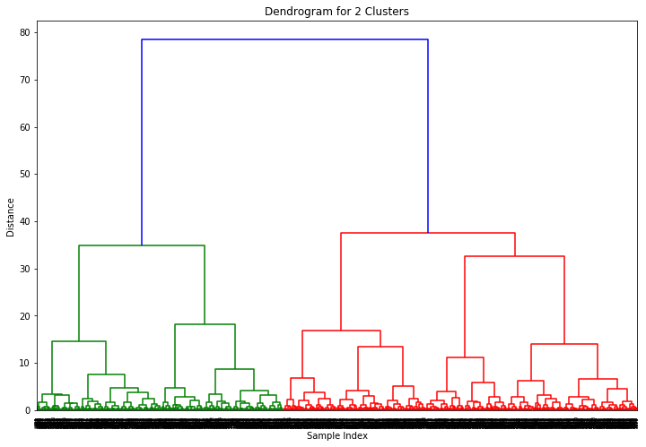

```python
n_clusters = 2
agglomerative = AgglomerativeClustering(n_clusters=n_clusters, affinity='euclidean', linkage='ward')
predicted_labels = agglomerative.fit_predict(X)
# Create the linkage matrix for dendrogram
linkage_matrix = sch.linkage(X, method='ward')

# Match predicted labels to true labels
matched_labels_agg = match_labels(true_labels, predicted_labels, len(np.unique(predicted_labels)))

# Plot the dendrogram
plt.figure(figsize=(12, 8))
sch.dendrogram(linkage_matrix)
plt.title(f'Dendrogram for {n_clusters} Clusters')
plt.xlabel('Sample Index')
plt.ylabel('Distance')
plt.show()
```

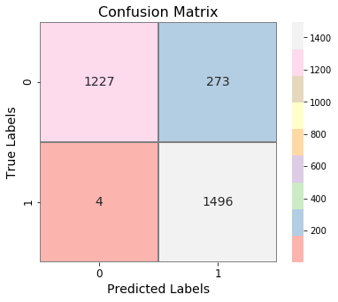

```python
# Confusion matrix
cm = confusion_matrix(true_labels, matched_labels_agg)

# Create the heatmap
plt.figure(figsize=(6, 5))
sns.heatmap(
    cm,
    annot=True,
    fmt='d',
    cmap='Pastel1',
    linewidths=0.3,
    linecolor='gray',
    annot_kws={"size": 14}
)
plt.title('Confusion Matrix', fontsize=16)
plt.xlabel('Predicted Labels', fontsize=14)
plt.ylabel('True Labels', fontsize=14)
plt.xticks(fontsize=12)
plt.yticks(fontsize=12)
plt.show()
```

```python
# Classification report
report = classification_report(true_labels, matched_labels_agg, output_dict=True)

report_df = pd.DataFrame(report).transpose()

# Display the report
print("Classification Report:")
report_df
```

```
Classification Report:
```

|  | precision | recall | f1-score | support |
| --- | --- | --- | --- | --- |
| 0 | 0.996751 | 0.818000 | 0.898572 | 1500.000000 |
| 1 | 0.845676 | 0.997333 | 0.915265 | 1500.000000 |
| accuracy | 0.907667 | 0.907667 | 0.907667 | 0.907667 |
| macro avg | 0.921213 | 0.907667 | 0.906918 | 3000.000000 |
| weighted avg | 0.921213 | 0.907667 | 0.906918 | 3000.000000 |

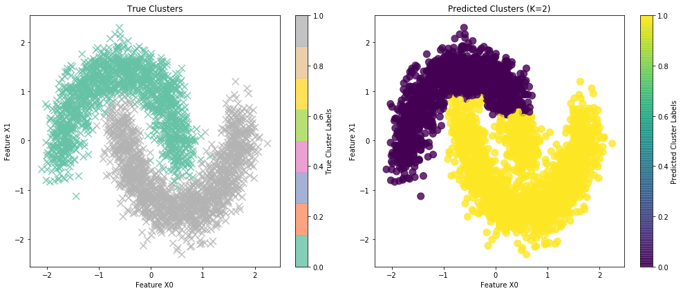

```python
# Enhanced side-by-side scatter plot with better visuals
plt.figure(figsize=(14, 6))

# Plot for true clusters
plt.subplot(1, 2, 1)
scatter_true = plt.scatter(X[:, 0], X[:, 1], c=true_labels, cmap='Set2', marker='x', alpha=0.8, s=100)
plt.title('True Clusters')
plt.xlabel('Feature X0')
plt.ylabel('Feature X1')
plt.colorbar(scatter_true, label='True Cluster Labels')

# Plot for predicted clusters
plt.subplot(1, 2, 2)
scatter_pred = plt.scatter(X[:, 0], X[:, 1], c=matched_labels_agg, cmap='viridis', marker='o', alpha=0.8, s=100)
plt.title('Predicted Clusters (K=2)')
plt.xlabel('Feature X0')
plt.ylabel('Feature X1')
plt.colorbar(scatter_pred, label='Predicted Cluster Labels')

plt.tight_layout()
plt.show()
```